# Part II - FIFA 2019 Dataset Explanatory Visualization

## by Paul Anugwom

## Investigation Overview

The goal of this presentation is to highlight key findings on this dataset.The target variable here is the value of players in the tournament.This presentation summarizes the major insights based on the relationship between the major independent variables and the dependent variable(Value of players).

## Dataset Overview

This dataset consists of all the details of the players who participated in the FIFA World Cup 2019 and their final value at which they were to be sold to other clubs.Data can be found in https://www.kaggle.com/datasets/blurredmachine/fifa-2019-world-cup-dataset.

## 10 Most Popular Nations in the Tournament

Interesting! England is the top footballing nation in the tournament with more players.Most of the players in the tournament are from Europe, followed by South America, then Asia.

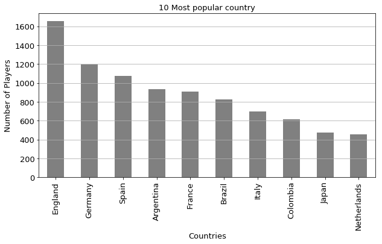

## Relationship Between Body-Type and Preferred-Foot

From below cluster bar chart,players with normal body type who are either left or right footed are more in the tournament.Most of the players with normal body type are right footed.Also, there are more right footed players in the tournament as compare to left footed players.

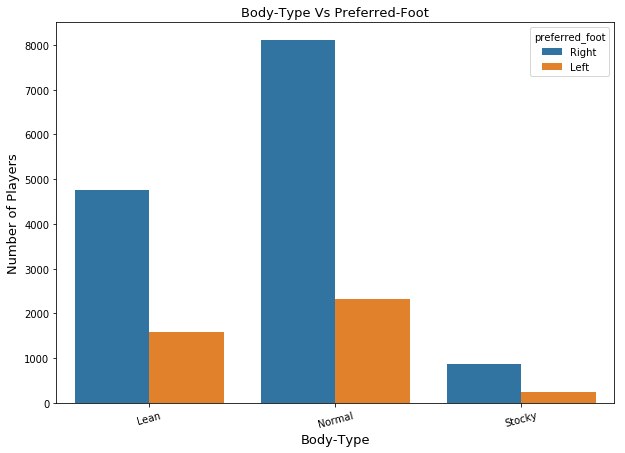

## Players Value and Internation-Reputation by Wage of Players

Plots below shows that players with high international reputation are more valued and also earns more.Moreover, more of the players in the tournament have low international reputation.

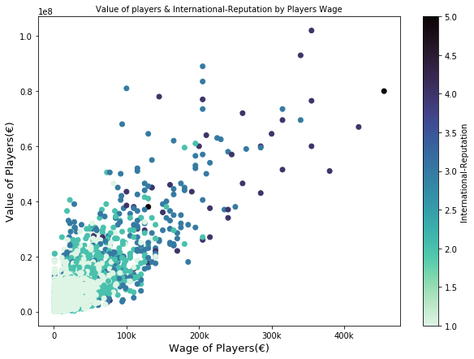

## Value & Wage of Players by Preferred Foot

More of left footed points are closer to the x and y axis,while more of the rigt footed points are farther away showing that more of the right footed players have high values and also earns more wages.

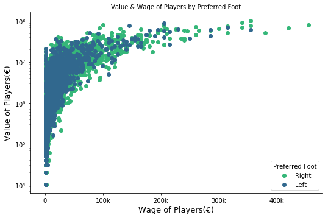

## Value & Wage of Players by Body Type

More of stocky body-type points are closer to the x and y axis,while more of the lean and normal body-types points are farther away showing that more of the lean and normal body-type players are more valued and also earns more wages.

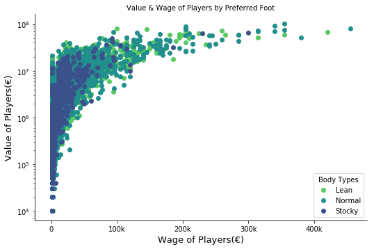

## Body Type & Value of Players by Preferred Foot

From the below lineplot, I observed that there is general increase in values in each cluster,from right foot to left foot in each body-type.Also, I observed that left footed players are most valuable. And in particular the Stocky left footed players are most valuable.

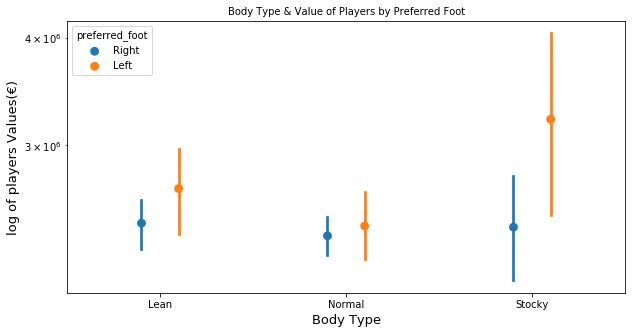

From the below lineplot,there is an increase in wage from right foot to left foot in each cluster. the stocky players who are left footed earns more than the lean and normal body-type players who are left footed.Also,stocky players who are right footed earns more than the lean and normal body-type players who are right foooted.

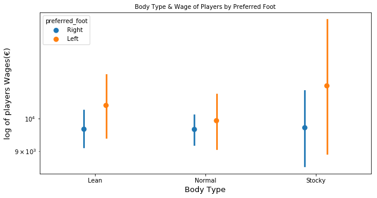